# FinalProj

## Guitar Price Prediction and Feature Importance Analysis

### Introduction

This notebook aims to explore and understand the factors influencing the price of guitars using a dataset of guitar specifications. The primary goal is to identify which features have the most significant effect on guitar prices through statistical modeling and visualization.

### Overall Task

The main objective is to analyze the `strat_data.xlsx` file to identify which feature has the greatest effect on the price of a guitar using linear regression, visualize the individual relationships and feature importances, and summarize the findings. Subsequently, a Random Forest Regression model will be implemented and evaluated to compare its predictive power.

### Analytical Steps

This notebook will cover the following key analytical steps:

1. **Data Loading and Initial Inspection**: Loading the `strat_data.xlsx` file into a pandas DataFrame and performing initial checks.
2. **Data Cleaning and Preprocessing**: Handling missing values, cleaning data types (e.g., 'Price', 'fretboard_radius'), and preparing features for modeling.
3. **Linear Regression Analysis**: Performing simple linear regressions for each feature against price, calculating R-squared values and coefficients.
4. **Visualization of Linear Relationships**: Creating scatter plots and bar charts to illustrate individual feature relationships and importances.
5. **Random Forest Regression**: Preparing data, training, and evaluating a Random Forest model for price prediction.
6. **Feature Importance from Random Forest**: Visualizing feature importances derived from the Random Forest model.
7. **Summary and Comparison**: Summarizing key findings from both linear and Random Forest regression models and comparing their effectiveness.

## Describe Dataset, DV and IVs

### Dataset Description

The `strat_data.xlsx` dataset contains information about various electric guitars, primarily focusing on Stratocaster-style guitars. Each row in the dataset represents a unique guitar listing, and the columns provide detailed attributes about these guitars. The information includes:

- **General Information:** `web_scraper_order`, `name`, `model`.
- **Pricing:** `Price` (the primary focus of our analysis).
- **Condition:** `Condition` (e.g., 'Used – Mint', 'Brand New').
- **Physical Attributes:** `body_style`, `color`, `fretboard_material`, `fretboard_radius`, `wood_top_style`, `finish_style`, `body_material`, `bridge_tailpiece_type`, `number_of_frets`.
- **Electronic Configuration:** `pickup_configuration`.
- **Origin and Age:** `country` of origin, `Year` of manufacture.
- **Color Family:** `color_family`.

### Dependent Variable (DV)

Our Dependent Variable (DV) for this analysis is **'Price'**. We aim to understand and predict how different guitar attributes influence the selling price of these instruments.

### Independent Variables (IVs) and Expected Influence

The Independent Variables (IVs) are all other relevant features in the dataset that are hypothesized to affect the 'Price' of a guitar. These include both numerical and categorical attributes, such as:

- **`Condition`**: The condition of the guitar (e.g., 'Brand New', 'Used – Mint', 'Used – Good') is expected to have a significant impact on price, with new or excellent condition guitars generally commanding higher prices.
- **`body_style`**: Different body styles might appeal to different markets or be associated with specific construction costs, thus influencing price.
- **`color` / `color_family`**: Certain colors or color families might be more popular or rare, affecting demand and ultimately price.
- **`country`**: The country of origin often indicates manufacturing quality, labor costs, and brand reputation, which are all strong determinants of a guitar's price (e.g., guitars from the USA or Japan might be pricier than those from Mexico or China).
- **`fretboard_material`**: Materials like Rosewood, Maple, or Ebony can affect playability, tone, and aesthetics, influencing manufacturing cost and desirability.
- **`fretboard_radius`**: This technical specification can affect playability, especially for different styles of music, potentially influencing niche market pricing.
- **`pickup_configuration`**: The type and arrangement of pickups (e.g., SSS, HSS, HH) directly impact the guitar's sound and versatility, which can be a major price factor.
- **`wood_top_style`**: The aesthetic and rarity of wood top styles (e.g., Flamed, Quilted) can add significantly to a guitar's value.
- **`finish_style`**: The type of finish (e.g., Gloss, Metallic, Satin) relates to both aesthetics and durability, contributing to perceived quality and price.
- **`body_material`**: The type of wood used for the body (e.g., Alder, Ash, Basswood, Mahogany) is a critical factor for tone, weight, and cost of production, directly impacting price.
- **`bridge_tailpiece_type`**: Different bridge systems (e.g., Tremolo Bridge, String-Through, Stop-Bar) offer varying functionality and are associated with different manufacturing complexities and player preferences, affecting price.
- **`number_of_frets`**: While less impactful than other features, the number of frets can slightly affect playability and design, contributing to overall value.
- **`Year`**: The vintage or newness of a guitar can affect its price, with certain vintage years being highly sought after, or newer models reflecting current market value.

These independent variables are expected to explain the variance in guitar prices because they represent a combination of material costs, craftsmanship, brand perception, aesthetic appeal, functional features, and market demand, all of which contribute to how a guitar is valued in the market.

## Data Loading and Initial Cleaning

```python
import pandas as pd # Import the pandas library for data manipulation

df = pd.read_excel('strat_data.xlsx') # Load the Excel file into a pandas DataFrame

print("First 5 rows of the DataFrame:")
print(df.head()) # Display the first 5 rows of the DataFrame to verify loading

print("\nDataFrame Information:")
df.info() # Display concise summary of the DataFrame, including data types and non-null values
```

```
First 5 rows of the DataFrame:
  web_scraper_order                                               name  \
0      1765740927-1  Fender Player II Stratocaster 2024 - Present -...
1      1765740930-2  Fender Limited Edition Tom DeLonge Signature S...
2      1765740933-3  Fender Player Plus Stratocaster with Maple Fre...
3      1765740936-4  Fender Player Series Stratocaster 2022 - Butte...
4      1765740939-5  Fender MIJ Aerodyne Custom Art Special Stratoc...

     Price    Condition  body_style            color  \
0     $675  Used – Mint  Solid Body      Birch Green
1     $675  Used – Mint  Solid Body       Surf Green
2     $750  Used – Mint  Solid Body    Olympic Pearl
3     $630  Used – Mint  Solid Body      Buttercream
4  $799.99  Used – Mint  Solid Body  California Blue

```

[output cut: 55 more lines]

### Clean 'Price' Column

**Reasoning**: Before any numerical analysis or regression, the 'Price' column must be cleaned and converted to a numeric data type. It currently contains currency symbols ('$') and commas (',') which are not recognized as numbers, making it unsuitable for mathematical operations. This step is essential to enable accurate calculations and modeling involving guitar prices.

```python
df['Price'] = df['Price'].astype(str).str.replace('$', '', regex=False).str.replace(',', '', regex=False) # Remove '$' and ',' from the 'Price' column
df['Price'] = pd.to_numeric(df['Price'], errors='coerce') # Convert the 'Price' column to a numeric data type, coercing errors to NaN

print("Price column after cleaning and conversion:")
print(df['Price'].head()) # Display the first 5 rows of the cleaned 'Price' column
print(df['Price'].dtype) # Display the data type of the 'Price' column
```

```
Price column after cleaning and conversion:
0    675.00
1    675.00
2    750.00
3    630.00
4    799.99
Name: Price, dtype: float64
float64
```

### Clean 'fretboard_radius' Column

**Reasoning**: The 'fretboard_radius' column contains string values with units (e.g., '9.5"', '12"') and potentially other non-numeric characters. To use this column for numerical analysis and regression, it must be cleaned by extracting only the numerical part and converting it to a float data type. This ensures that the radius values are uniformly represented and suitable for mathematical operations.

```python
df['fretboard_radius'] = df['fretboard_radius'].astype(str).str.extract('(\\d+\\.?\\d*)').astype(float) # Extract numerical part using regex and convert to float

print("Fretboard radius column after cleaning and conversion:")
print(df['fretboard_radius'].head()) # Display the first 5 rows of the cleaned 'fretboard_radius' column
print(df['fretboard_radius'].dtype) # Display the data type of the 'fretboard_radius' column
```

```
Fretboard radius column after cleaning and conversion:
0     9.5
1     9.5
2    12.0
3     9.5
4    12.0
Name: fretboard_radius, dtype: float64
float64
```

## Perform Exploratory Data Analysis (EDA)

### Subtask:

Add new code cells to generate descriptive statistics for both numerical and categorical features. Integrate the existing average price bar charts for categorical attributes, ensuring they are presented as part of the early visualizations in this EDA section.

**Reasoning**: The first step for performing EDA is to generate descriptive statistics for the numerical features to understand their central tendency, dispersion, and shape.

```python
numerical_features = ['number_of_frets', 'fretboard_radius']
categorical_features = [
    'Condition',
    'body_style',
    'country',
    'fretboard_material',
    'color_family',
    'pickup_configuration',
    'wood_top_style',
    'finish_style',
    'body_material',
    'bridge_tailpiece_type'
]

print(f"Selected Numerical Features: {numerical_features}")
print(f"Selected Categorical Features: {categorical_features}")


print("Descriptive statistics for numerical features:")
print(df[numerical_features].describe())
```

```
Selected Numerical Features: ['number_of_frets', 'fretboard_radius']
Selected Categorical Features: ['Condition', 'body_style', 'country', 'fretboard_material', 'color_family', 'pickup_configuration', 'wood_top_style', 'finish_style', 'body_material', 'bridge_tailpiece_type']
Descriptive statistics for numerical features:
       number_of_frets  fretboard_radius
count      2136.000000       1805.000000
mean         21.647004          9.479501
std           0.542283          1.454477
min          20.000000          7.250000
25%          21.000000          9.500000
50%          22.000000          9.500000
75%          22.000000          9.500000
max          24.000000         17.000000
```

**Reasoning**: The next step is to generate descriptive statistics for all categorical features in the DataFrame `df` using the `.describe()` method with `include='object'` to understand their distribution and unique values.

```python
print("\nDescriptive statistics for categorical features:")
print(df[categorical_features].describe(include='object'))
```

```
Descriptive statistics for categorical features:
               Condition  body_style        country fretboard_material  \
count               2132        2122           1939               1960
unique                 6           3              4                  5
top     Used – Excellent  Solid Body  United States           Rosewood
freq                1106        2105           1060                882

       color_family pickup_configuration wood_top_style finish_style  \
count          1943                 1962           1563         1903
unique           14                    7              5            3
top           Brown                  SSS         Opaque        Gloss
freq            382                 1412           1111         1448

       body_material bridge_tailpiece_type
count           1905                  1960
unique             6                     5
top            Alder        Tremolo Bridge
freq            1552                  1698
```

**Reasoning**: The next step is to calculate the average 'Price' for each category within the `categorical_features` and then integrate the existing average price bar charts for categorical attributes.

## "Price vs Features" bar charts for fun

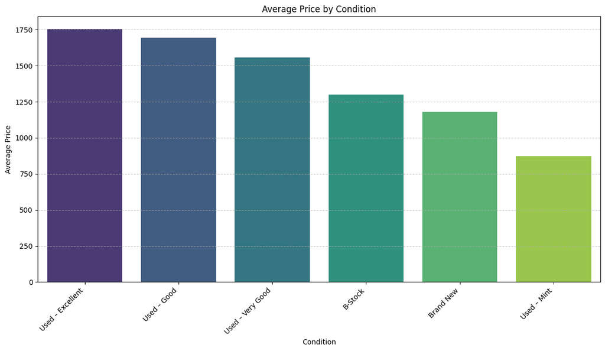

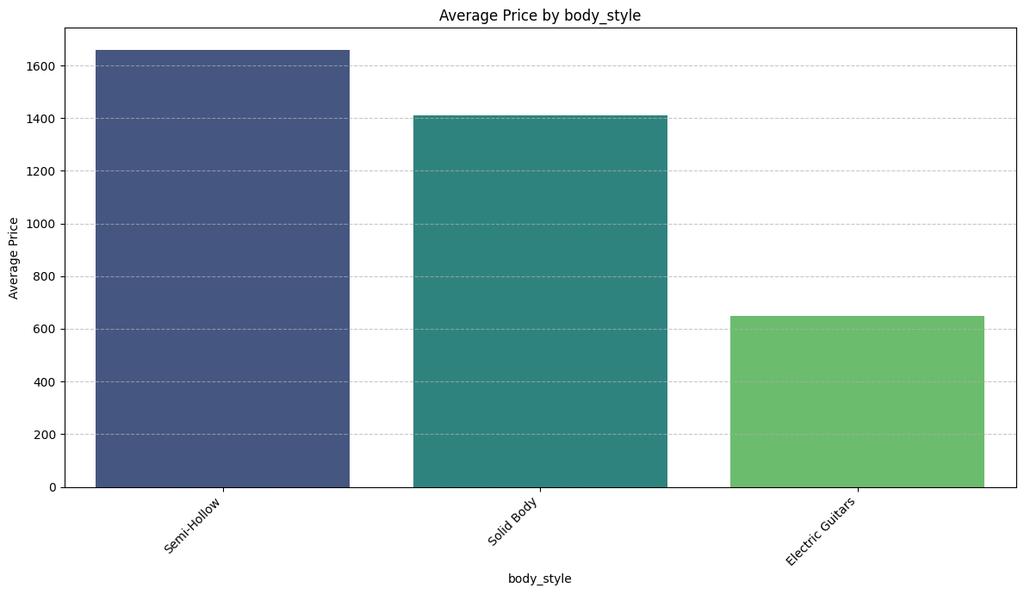

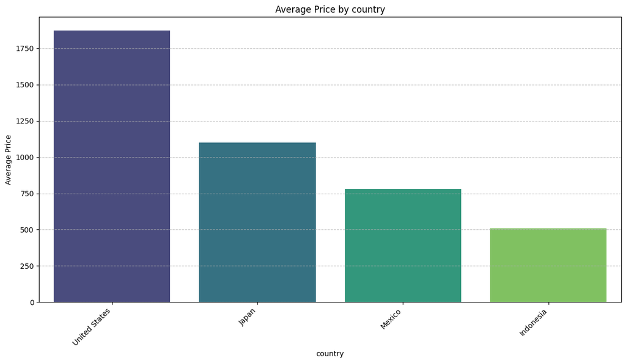

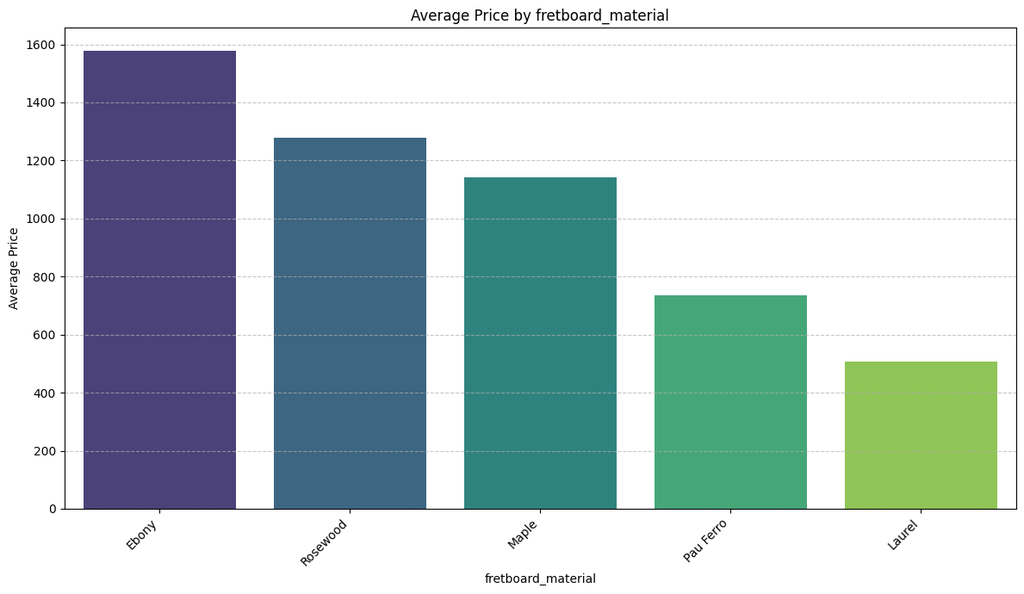

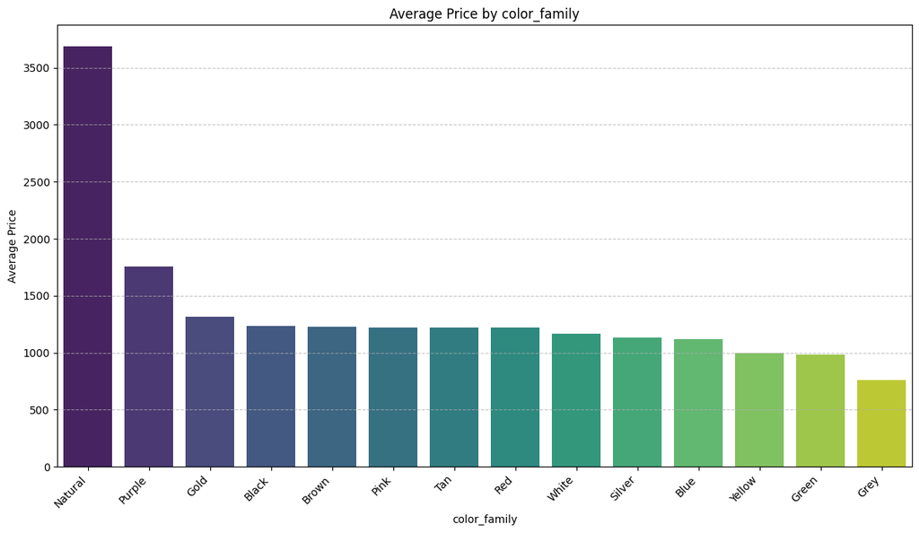

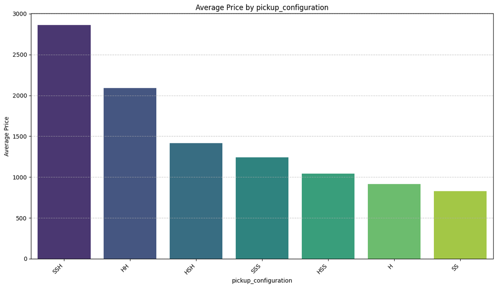

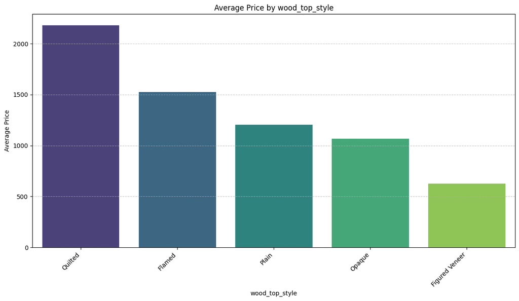

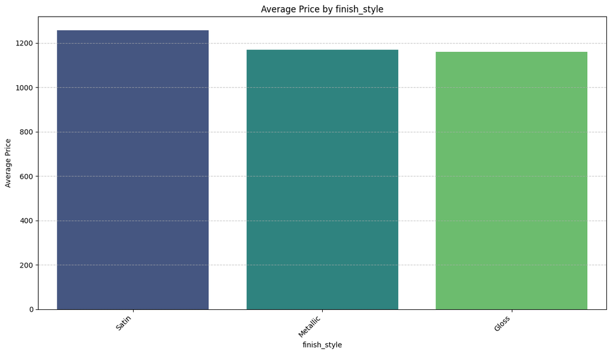

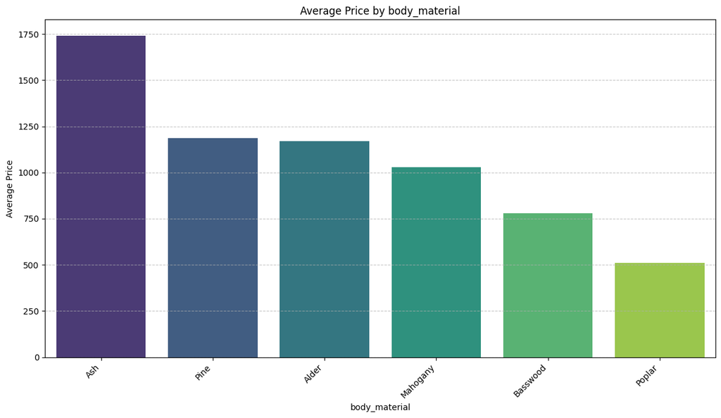

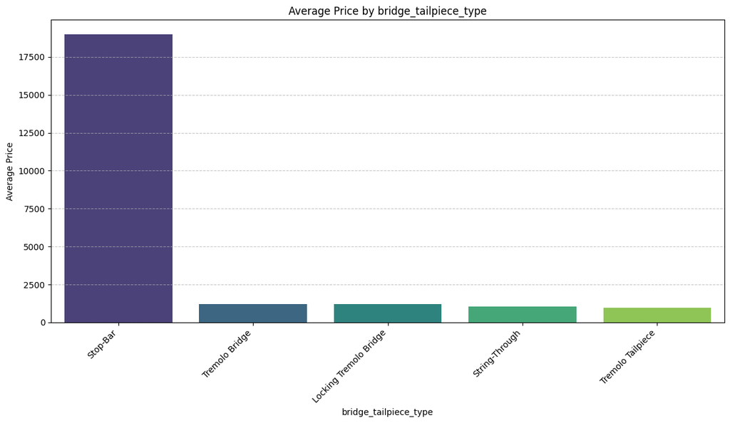

```
Generated bar charts showing average price per categorical attribute.
```

```python
import matplotlib.pyplot as plt
import seaborn as sns

for feature in categorical_features:
    # Calculate the average price for each category
    average_prices = df.groupby(feature)['Price'].mean().sort_values(ascending=False).reset_index()

    plt.figure(figsize=(12, 7))
    sns.barplot(x=feature, y='Price', data=average_prices, hue=feature, palette='viridis', legend=False)
    plt.title(f'Average Price by {feature}')
    plt.xlabel(feature)
    plt.ylabel('Average Price')
    plt.xticks(rotation=45, ha='right')
    plt.grid(axis='y', linestyle='--', alpha=0.7)
    plt.tight_layout()
    plt.show()
    plt.clf()

print("Generated bar charts showing average price per categorical attribute.")
```

## Linear Regression Analysis

### What is Linear Regression?

Linear Regression is a fundamental statistical and machine learning technique used to model the relationship between a dependent variable (target) and one or more independent variables (features) by fitting a linear equation to the observed data. The goal is to find the best-fitting straight line (or hyperplane in higher dimensions) that minimizes the sum of the squared differences between the observed and predicted values.

#### Mathematical Background

For simple linear regression (one independent variable), the model is represented as:

$$Y = \beta_0 + \beta_1X + \epsilon$$

Where:

- $Y$ is the dependent variable (Price).
- $X$ is the independent variable (e.g., `number_of_frets`, `fretboard_radius`).
- $\beta_0$ is the y-intercept (the predicted value of Y when X is 0).
- $\beta_1$ is the coefficient of X (the change in Y for a one-unit change in X).
- $\epsilon$ is the error term, representing the unobserved factors and random variability.

For multiple linear regression (multiple independent variables), the model extends to:

$$Y = \beta_0 + \beta_1X_1 + \beta_2X_2 + ... + \beta_nX_n + \epsilon$$

The coefficients ($\beta$ values) are estimated using the Ordinary Least Squares (OLS) method, which seeks to minimize the sum of the squared residuals (the differences between actual and predicted Y values):

$$\text{Minimize } \sum_{i=1}^{m} (y_i - \hat{y}_i)^2$$

Where $y_i$ is the actual value, and $\hat{y}_i$ is the predicted value for the $i$-th observation.

### Strengths of Linear Regression

1. **Interpretability**: The coefficients of a linear regression model directly indicate the strength and direction of the relationship between each independent variable and the dependent variable. This makes it very easy to understand how each feature influences the outcome.
2. **Simplicity and Computational Efficiency**: Linear regression is computationally inexpensive and easy to implement. It provides a quick and straightforward way to model relationships in data.
3. **Baseline Model**: Due to its simplicity and interpretability, linear regression often serves as an excellent baseline model against which more complex models (like Random Forests) can be compared. If a more complex model doesn't significantly outperform linear regression, the simpler model might be preferred for its ease of understanding and deployment.
4. **Statistical Inference**: Linear regression comes with a rich statistical theory, allowing for hypothesis testing, confidence intervals for coefficients, and various diagnostic plots to assess model fit and assumptions.

### Weaknesses of Linear Regression

1. **Assumption of Linearity**: Linear regression assumes a linear relationship between the independent and dependent variables. If the true relationship is non-linear, the model will not accurately capture it, leading to poor predictions.
2. **Sensitivity to Outliers**: Linear regression, especially the OLS method, is sensitive to outliers. Outliers can heavily influence the estimated coefficients, potentially distorting the true relationship and leading to a misleading model.
3. **Homoscedasticity**: It assumes that the variance of the errors is constant across all levels of the independent variables (homoscedasticity). Violations of this assumption can lead to inefficient coefficient estimates and incorrect standard errors.
4. **Multicollinearity**: If independent variables are highly correlated with each other (multicollinearity), it can make the coefficient estimates unstable and difficult to interpret.
5. **Inability to Capture Complex Relationships**: Linear regression cannot inherently model complex, non-linear patterns or interactions between features unless these are explicitly engineered into the model (e.g., by adding polynomial terms or interaction terms).

### Why Linear Regression was chosen for Initial Analysis?

Linear Regression was chosen as the initial analysis method for several key reasons:

1. **Interpretability**: Our primary goal is to understand *which features* have the greatest effect on guitar prices. Linear regression provides clear, interpretable coefficients and R-squared values that directly indicate the strength and direction of each feature's individual relationship with price. This makes it easy to identify initial drivers and explain their impact.
2. **Baseline Understanding**: Before delving into more complex models, establishing a baseline understanding with a simpler model is crucial. Linear regression helps us quickly identify straightforward linear relationships and provides a benchmark against which the performance of more advanced models (like Random Forest) can be measured.
3. **Simplicity and Speed**: It is computationally efficient, allowing for a quick initial scan of many features to pinpoint those with potential linear associations with the target variable, even if the overall R-squared for a single variable is low.
4. **Identifying Direct Impacts**: While guitar pricing is complex, linear regression can help reveal direct, additive effects of features, such as how much an extra fret might change the price, or the average price difference attributed to a specific country of origin.

### Define Feature Lists

**Reasoning**: Before performing linear regression, it's essential to explicitly define which columns will be treated as numerical and which as categorical. This step helps in organizing the analysis, ensuring that appropriate preprocessing (like one-hot encoding for categorical features) is applied, and excluding irrelevant columns from the regression models. The selected features are those deemed potentially influential on the 'Price' of a guitar.

### Initialize Regression Results Storage

**Reasoning**: To systematically store and retrieve the outcomes of individual linear regressions for each feature, it is necessary to initialize an empty dictionary. This dictionary, `regression_results`, will serve as a structured container for the R-squared values and coefficients derived from each regression, making it easier to analyze and compare the impact of different features on the guitar price.

```python
regression_results = {} # Initialize an empty dictionary to store regression results for each feature
print("Initialized empty dictionary 'regression_results'.")
```

```
Initialized empty dictionary 'regression_results'.
```

### Perform Linear Regression for Numerical Features

**Reasoning**: Simple linear regression will be performed for each numerical feature to assess its individual linear relationship with 'Price'. This involves fitting a model for each feature against the target variable, calculating the R-squared value to quantify the proportion of variance in 'Price' explained by the feature, and determining the coefficient to understand the direction and magnitude of their relationship. The results will be stored in the `regression_results` dictionary for subsequent analysis and visualization.

```python
from sklearn.linear_model import LinearRegression # Import LinearRegression model for fitting
from sklearn.metrics import r2_score # Import r2_score to evaluate model performance

for feature in numerical_features:
    temp_df = df[['Price', feature]].dropna() # Create a temporary DataFrame with 'Price' and the current feature, dropping rows with NaN values
    if not temp_df.empty:
        X = temp_df[[feature]] # Independent variable (feature)
        y = temp_df['Price'] # Dependent variable (Price)

        model = LinearRegression() # Initialize the Linear Regression model
        model.fit(X, y) # Fit the model to the data

        y_pred = model.predict(X) # Make predictions using the fitted model
        r_squared = r2_score(y, y_pred) # Calculate the R-squared value
        coefficient = model.coef_[0] # Extract the coefficient of the feature

        regression_results[feature] = {
            'r_squared': r_squared,
            'coefficient': coefficient
        }
print("Performed linear regressions for numerical features.")
```

```
Performed linear regressions for numerical features.
```

### Perform Linear Regression for Categorical Features

```python
for feature in categorical_features:
    # Fill missing values with the mode of the respective column
    df[feature] = df[feature].fillna(df[feature].mode()[0])

    # Apply one-hot encoding to convert categorical feature into numerical binary columns
    # drop_first=True avoids multicollinearity by making one category the baseline
    one_hot_encoded_df = pd.get_dummies(df[[feature]], prefix=feature, drop_first=True, dtype=int)

    # Iterate through each newly created one-hot encoded binary column
    for col in one_hot_encoded_df.columns:
        # Create a temporary DataFrame for 'Price' and the current one-hot encoded column, dropping NaNs
        temp_df = pd.concat([df['Price'], one_hot_encoded_df[col]], axis=1).dropna()

        if not temp_df.empty:
            X = temp_df[[col]] # Independent variable (one-hot encoded category)
            y = temp_df['Price'] # Dependent variable (Price)

            model = LinearRegression() # Initialize the Linear Regression model
            model.fit(X, y) # Fit the model to the data

            y_pred = model.predict(X) # Make predictions using the fitted model
            r_squared = r2_score(y, y_pred) # Calculate the R-squared value
            coefficient = model.coef_[0] # Extract the coefficient of the feature

            # Store the R-squared and coefficient in the regression_results dictionary
            regression_results[col] = {
                'r_squared': r_squared,
                'coefficient': coefficient
            }
print("Performed linear regressions for categorical features.")
```

```
Performed linear regressions for categorical features.
```

### Summarize Linear Regression Results

**Reasoning**: After performing individual linear regressions for all numerical and one-hot encoded categorical features, it is crucial to review and interpret the results. This step involves printing the collected `regression_results` dictionary, which contains the R-squared values and coefficients for each feature. The R-squared value indicates the proportion of variance in 'Price' explained by that single feature, while the coefficient quantifies the linear impact (direction and magnitude) of the feature on 'Price'. A positive coefficient means an increase in the feature's value (or presence for categorical features) is associated with an increase in price, and vice-versa for a negative coefficient.

```python
print("Regression Results:")
for feature, metrics in regression_results.items():
    print(f"Feature: {feature}, R-squared: {metrics['r_squared']:.4f}, Coefficient: {metrics['coefficient']:.4f}")
```

```
Regression Results:
Feature: number_of_frets, R-squared: 0.0931, Coefficient: -642.1855
Feature: fretboard_radius, R-squared: 0.0321, Coefficient: -86.6885
Feature: Condition_Brand New, R-squared: 0.0098, Coefficient: -286.1131
Feature: Condition_Used – Excellent, R-squared: 0.0978, Coefficient: 715.1429
Feature: Condition_Used – Good, R-squared: 0.0009, Coefficient: 291.2370
Feature: Condition_Used – Mint, R-squared: 0.0776, Coefficient: -725.5675
Feature: Condition_Used – Very Good, R-squared: 0.0002, Coefficient: 149.0368
Feature: body_style_Semi-Hollow, R-squared: 0.0004, Coefficient: 253.0507
Feature: body_style_Solid Body, R-squared: 0.0002, Coefficient: -193.1645
Feature: country_Japan, R-squared: 0.0056, Coefficient: -331.6117
Feature: country_Mexico, R-squared: 0.1470, Coefficient: -933.3500
Feature: country_United States, R-squared: 0.1801, Coefficient: 985.1958
Feature: fretboard_material_Laurel, R-squared: 0.0056, Coefficient: -910.8231
Feature: fretboard_material_Maple, R-squared: 0.0375, Coefficient: -450.2983
Feature: fretboard_material_Pau Ferro, R-squared: 0.0192, Coefficient: -710.7304
Feature: fretboard_material_Rosewood, R-squared: 0.0653, Coefficient: 583.6922
Feature: color_family_Blue, R-squared: 0.0120, Coefficient: -342.7415
Feature: color_family_Brown, R-squared: 0.1238, Coefficient: 905.8138
Feature: color_family_Gold, R-squared: 0.0001, Coefficient: -93.2311
Feature: color_family_Green, R-squared: 0.0131, Coefficient: -467.7456
Feature: color_family_Grey, R-squared: 0.0023, Coefficient: -653.8816
Feature: color_family_Natural, R-squared: 0.0131, Coefficient: 2289.0149
Feature: color_family_Pink, R-squared: 0.0006, Coefficient: -190.3846
Feature: color_family_Purple, R-squared: 0.0011, Coefficient: 352.9173
Feature: color_family_Red, R-squared: 0.0033, Coefficient: -211.5139
Feature: color_family_Silver, R-squared: 0.0019, Coefficient: -285.7797
Feature: color_family_Tan, R-squared: 0.0001, Coefficient: -187.5692
Feature: color_family_White, R-squared: 0.0082, Coefficient: -287.6562
Feature: color_family_Yellow, R-squared: 0.0045, Coefficient: -426.3009
Feature: pickup_configuration_HH, R-squared: 0.0035, Coefficient: 689.7435
Feature: pickup_configuration_HSH, R-squared: 0.0000, Coefficient: 5.6881
Feature: pickup_configuration_HSS, R-squared: 0.0264, Coefficient: -459.0279
Feature: pickup_configuration_SS, R-squared: 0.0021, Coefficient: -585.7003
Feature: pickup_configuration_SSH, R-squared: 0.0015, Coefficient: 1452.5349
Feature: pickup_configuration_SSS, R-squared: 0.0300, Coefficient: 452.1975
Feature: wood_top_style_Flamed, R-squared: 0.0002, Coefficient: 117.3363
Feature: wood_top_style_Opaque, R-squared: 0.0059, Coefficient: 215.3692
Feature: wood_top_style_Plain, R-squared: 0.0074, Coefficient: -253.0554
Feature: wood_top_style_Quilted, R-squared: 0.0011, Coefficient: 774.8003
Feature: finish_style_Metallic, R-squared: 0.0106, Coefficient: -296.6505
Feature: finish_style_Satin, R-squared: 0.0003, Coefficient: -154.8916
Feature: body_material_Ash, R-squared: 0.0059, Coefficient: 355.2170
Feature: body_material_Basswood, R-squared: 0.0152, Coefficient: -661.5228
Feature: body_material_Mahogany, R-squared: 0.0016, Coefficient: -386.7160
Feature: body_material_Pine, R-squared: 0.0009, Coefficient: -228.6321
Feature: body_material_Poplar, R-squared: 0.0103, Coefficient: -912.1791
Feature: bridge_tailpiece_type_Stop-Bar, R-squared: 0.1110, Coefficient: 17599.4111
Feature: bridge_tailpiece_type_String-Through, R-squared: 0.0063, Coefficient: -385.7785
Feature: bridge_tailpiece_type_Tremolo Bridge, R-squared: 0.0084, Coefficient: 319.2498
Feature: bridge_tailpiece_type_Tremolo Tailpiece, R-squared: 0.0053, Coefficient: -461.6580
```

## Visualize Regression Relationships

### Import Visualization Libraries

**Reasoning**: To visualize the relationships between features and 'Price', and to plot feature importances, it is necessary to import `matplotlib.pyplot` for general plotting functionalities and `seaborn` for creating aesthetically pleasing statistical graphics, including regression plots and bar charts. These libraries provide the tools needed to generate the required visualizations effectively.

```python
import matplotlib.pyplot as plt # Import matplotlib for basic plotting functionalities
import seaborn as sns # Import seaborn for enhanced statistical data visualization

print("Imported matplotlib.pyplot as plt and seaborn as sns.")
```

```
Imported matplotlib.pyplot as plt and seaborn as sns.
```

## Integrate and Comment Linear Regression Execution & Visualization

### Prepare Data for Visualization

To effectively visualize the relationships for all features, including categorical ones, it's necessary to prepare the DataFrame by applying one-hot encoding to all categorical features. This process transforms categorical variables into a numerical format, creating new binary columns for each category. By concatenating these one-hot encoded columns back to the main DataFrame, we ensure that every feature (both original numerical and newly created binary categorical) for which regressions were performed is present and ready for plotting. This consolidated DataFrame, `df_plot`, allows for consistent iteration and visualization across all analyzed features.

```python
df_plot = df.copy() # Create a copy of the original DataFrame to avoid modifying it directly for plotting purposes.

for feature in categorical_features:
    # One-hot encode the categorical feature. drop_first=True ensures multicollinearity is avoided by making one category the baseline.
    one_hot_encoded_df = pd.get_dummies(df_plot[[feature]], prefix=feature, drop_first=True, dtype=int)
    # Concatenate the one-hot encoded columns to the DataFrame for plotting.
    df_plot = pd.concat([df_plot, one_hot_encoded_df], axis=1)

print("DataFrame prepared with one-hot encoded columns for plotting.")
```

```
DataFrame prepared with one-hot encoded columns for plotting.
```

### Visualize Categorical Feature Impacts

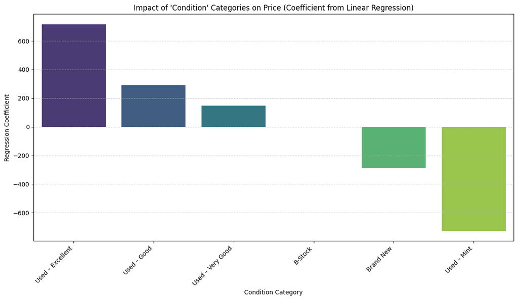

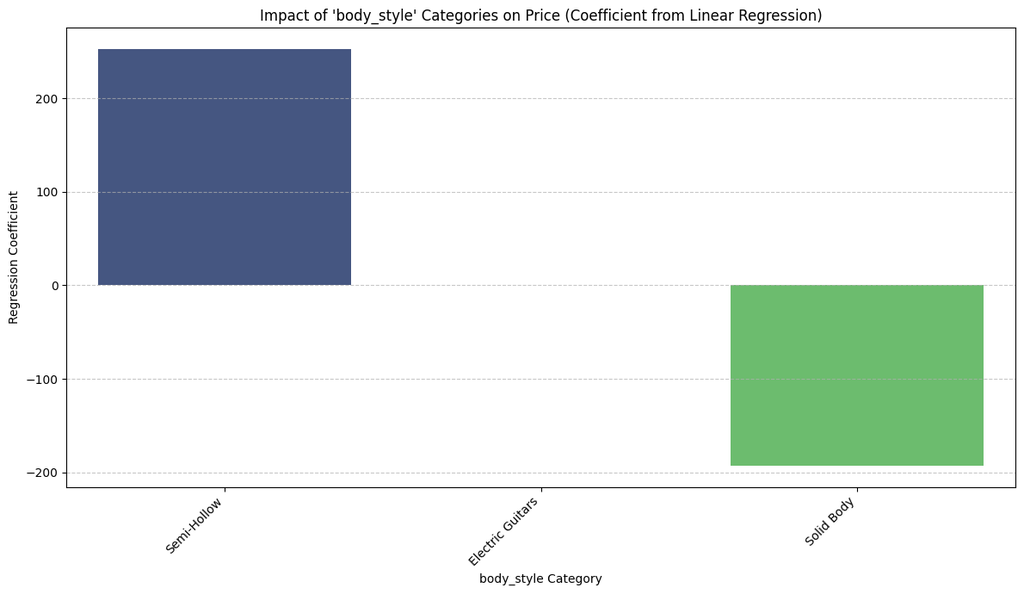

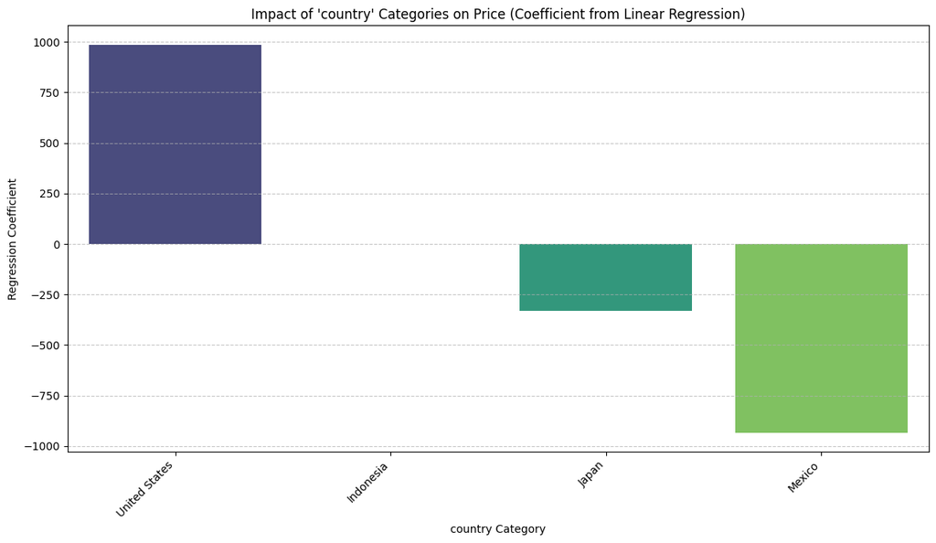

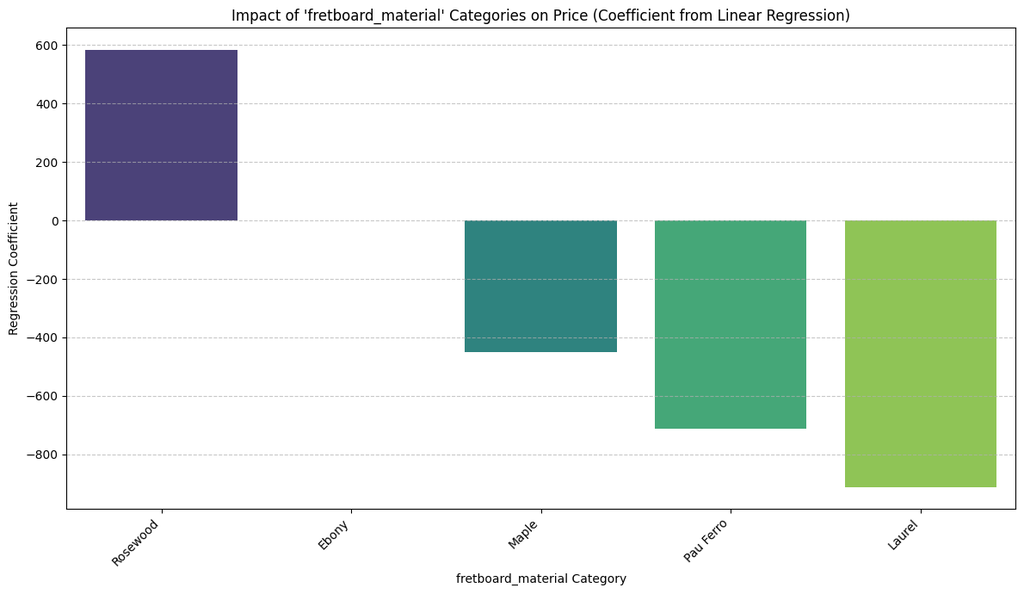

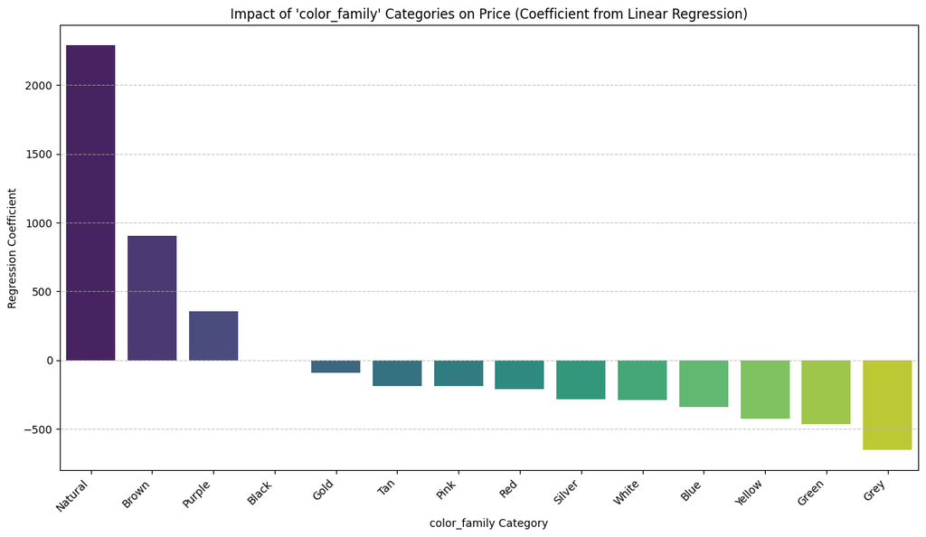

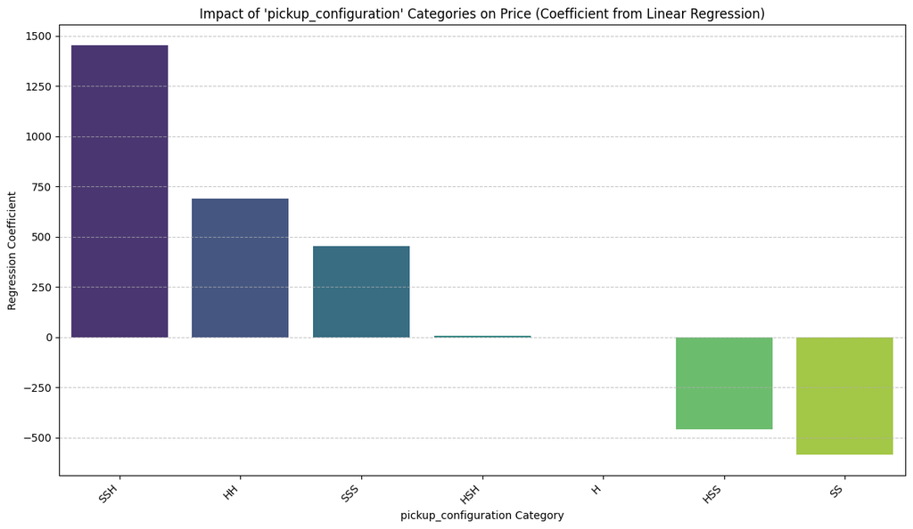

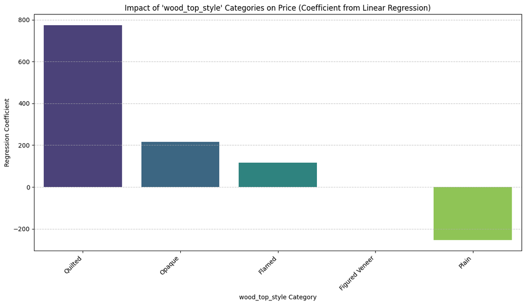

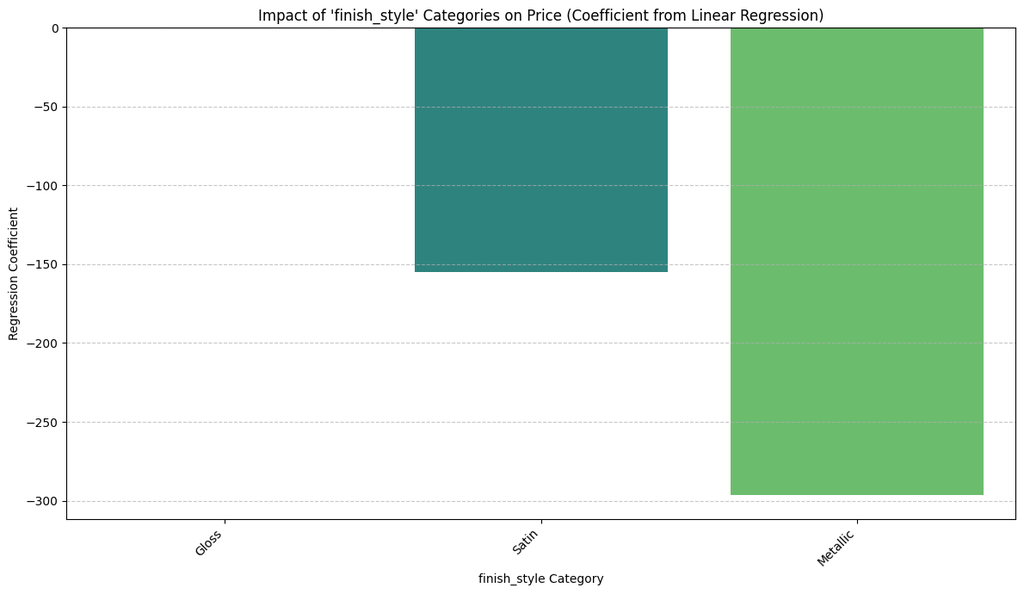

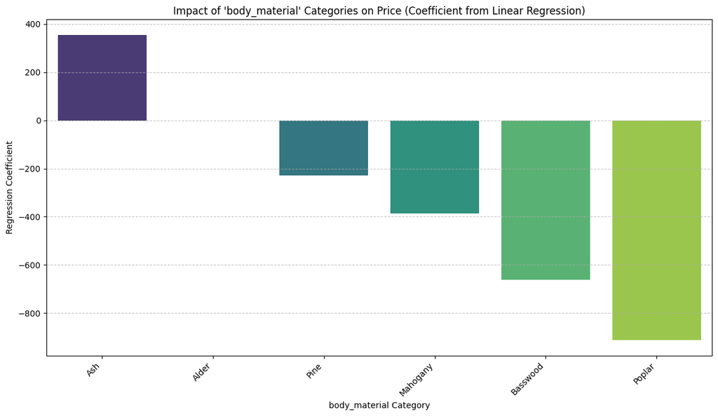

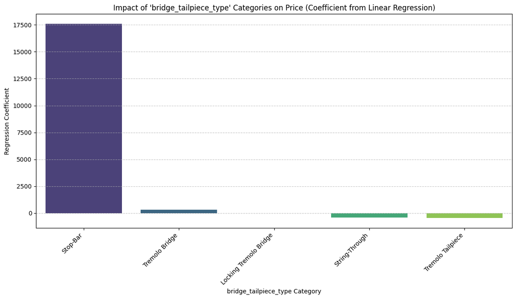

```
Generated grouped bar charts for categorical feature impacts.
```

```python
for original_feature in categorical_features:
    category_coefficients = []

    # Get all unique categories for the original feature from the mode-imputed df
    all_categories = df[original_feature].unique().tolist()

    # Find the base category (the one not present in the one-hot encoded results due to drop_first=True)
    encoded_prefix = f"{original_feature}_"
    encoded_category_names = [col.replace(encoded_prefix, "") for col in regression_results.keys() if col.startswith(encoded_prefix)]

    base_category = None
    for cat in all_categories:
        if cat not in encoded_category_names:
            base_category = cat
            break

    # Assign a coefficient of 0.0 to the base category for comparison
    if base_category is not None: # Ensure a base category was found
        category_coefficients.append({'Category': base_category, 'Coefficient': 0.0})

    # Collect coefficients for all other encoded categories
    for encoded_col_name, metrics in regression_results.items():
        if encoded_col_name.startswith(encoded_prefix):
            category_name = encoded_col_name.replace(encoded_prefix, "")
            coefficient = metrics['coefficient']
            category_coefficients.append({'Category': category_name, 'Coefficient': coefficient})

    # Plot if there are categories to show
    if category_coefficients:
        coefficients_df = pd.DataFrame(category_coefficients)
        # Sort coefficients for better visualization
        coefficients_df = coefficients_df.sort_values(by='Coefficient', ascending=False)

        plt.figure(figsize=(12, 7))
        # Create a bar plot of coefficients for each category
        sns.barplot(x='Category', y='Coefficient', data=coefficients_df, hue='Category', palette='viridis', legend=False)
        plt.title(f"Impact of '{original_feature}' Categories on Price (Coefficient from Linear Regression)")
        plt.xlabel(f"{original_feature} Category")
        plt.ylabel("Regression Coefficient")
        plt.xticks(rotation=45, ha='right')
        plt.grid(axis='y', linestyle='--', alpha=0.7)
        plt.tight_layout()
        plt.show()
        plt.clf() # Clear the current figure

print("Generated grouped bar charts for categorical feature impacts.")
```

### Visualize Feature Importance (R-squared)

## Integrate and Comment Linear Regression Execution & Visualization

### Subtask:

Visualize the R-squared values for feature importance using a bar chart and analyze the results.

### Analyze Feature Importance (R-squared)

A bar chart of R-squared values is used to visually represent the individual importance of each feature in predicting guitar prices. Each bar on the chart corresponds to a feature, and its height indicates the R-squared value obtained from the simple linear regression of that feature against the 'Price'. A higher R-squared value signifies a stronger linear relationship, meaning that the feature, when considered in isolation, explains a larger proportion of the variance in guitar prices. This visualization allows for a quick comparison of the individual predictive power of each feature and helps identify which ones have the most significant linear impact on the dependent variable.

**Reasoning**: As per instruction 3, I will move the code cell that generates the feature importance bar chart based on R-squared values (`8e4c69cd`) to this section and add comments to explain the extraction of R-squared values, sorting them, and the plotting process using `sns.barplot`.

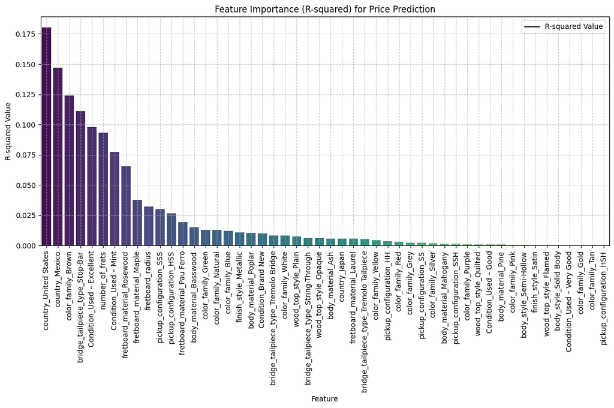

```
Generated bar chart of feature importance based on R-squared values.
```

```python
r_squared_values = {
    feature: metrics['r_squared'] # Extract the R-squared value for each feature from the regression_results dictionary
    for feature, metrics in regression_results.items()
}

r_squared_series = pd.Series(r_squared_values).sort_values(ascending=False) # Convert R-squared values to a pandas Series and sort in descending order

plt.figure(figsize=(12, 8)) # Set the figure size for the bar chart
sns.barplot(x=r_squared_series.index, y=r_squared_series.values, hue=r_squared_series.index, palette='viridis', legend=False) # Create a bar plot using seaborn
plt.xticks(rotation=90) # Rotate x-axis labels for better readability
plt.xlabel('Feature') # Set x-axis label
plt.ylabel('R-squared Value') # Set y-axis label
plt.title('Feature Importance (R-squared) for Price Prediction') # Set the title of the plot
plt.legend(labels=['R-squared Value']) # Add a legend for the R-squared values
plt.grid(True, linestyle='--', alpha=0.7) # Add a grid for better readability
plt.tight_layout() # Adjust layout to prevent labels from overlapping
plt.show() # Display the plot

print("Generated bar chart of feature importance based on R-squared values.")
```

### Analysis of R-squared Feature Importance

The bar chart of R-squared values clearly highlights which features, when considered individually, have the strongest linear relationship with guitar prices. The higher the R-squared value, the more variance in price that particular feature can explain on its own.

**Top Features by R-squared Value:**

1. **`country_United States` (R-squared: 0.1801, Coefficient: 985.1958)**: This feature has the highest R-squared, indicating that whether a guitar is manufactured in the United States explains approximately 18.01% of the variance in price. The positive coefficient suggests that guitars from the United States are, on average, $985.19 more expensive than the baseline country (likely 'Mexico' or another omitted category due to `drop_first=True` and the actual distribution of data). This implies a strong premium associated with US-made guitars.
2. **`country_Mexico` (R-squared: 0.1470, Coefficient: -933.3500)**: Guitars from Mexico also show a significant individual linear relationship, explaining about 14.70% of the price variance. The negative coefficient of -$933.35 suggests that Mexican-made guitars are, on average, less expensive than the baseline.
3. **`color_family_Brown` (R-squared: 0.1238, Coefficient: 905.8138)**: Belonging to the 'Brown' color family explains 12.38% of the price variance. The positive coefficient of $905.81 suggests that guitars in this color family tend to be significantly more expensive than those in the baseline color family.
4. **`bridge_tailpiece_type_Stop-Bar` (R-squared: 0.1110, Coefficient: 17599.4111)**: This feature, while having a relatively high R-squared of 0.1110 (11.10% of variance explained), exhibits an exceptionally high coefficient of $17599.41. This suggests a very strong positive association with price. Such a large coefficient might indicate that guitars with a 'Stop-Bar' bridge are typically found in a much higher price segment or that this category represents a very small, high-value niche. Further investigation would be needed to confirm this, as an R-squared of 0.1110 might not fully support such a drastic coefficient in a simple linear model.
5. **`Condition_Used – Excellent` (R-squared: 0.0978, Coefficient: 715.1429)**: The condition 'Used – Excellent' explains nearly 9.78% of the price variance. The positive coefficient of $715.14 indicates that guitars in excellent used condition are, on average, significantly pricier compared to the baseline condition.

**Implications of High R-squared Values:** These features demonstrate a notable individual linear relationship with price. For instance, the country of origin seems to be a very strong indicator of price, likely reflecting differences in manufacturing cost, brand perception, and material quality. The presence of a 'Stop-Bar' bridge, though potentially a niche, also stands out. The condition of the guitar also plays a predictable role.

**Features with Very Low R-squared Values:** Many features, such as `pickup_configuration_HSH` (R-squared: 0.0000), `color_family_Gold` (R-squared: 0.0001), `color_family_Tan` (R-squared: 0.0001), `Condition_Used – Very Good` (R-squared: 0.0002), `body_style_Solid Body` (R-squared: 0.0002), and `wood_top_style_Flamed` (R-squared: 0.0002), exhibit extremely low R-squared values. This suggests that these features, when considered in isolation, have a negligible linear relationship with the guitar's price. Their presence or absence (or value, for numerical features) in a simple linear model explains almost none of the variability in price. While they might still be important in a more complex, multivariate model, their individual linear impact is minimal.

## Random Forest Regression Analysis

### What is Random Forest Regression?

Random Forest Regression is an ensemble learning method that operates by constructing a multitude of decision trees during training and outputting the mean prediction (regression) of the individual trees. It is a powerful and versatile algorithm known for its high accuracy and ability to handle various types of data.

#### Mathematical Background

**1. Decision Trees:** The fundamental building block of a Random Forest is the Decision Tree. A decision tree recursively splits the data into subsets based on feature values, creating a tree-like structure of decisions. For regression, the prediction at each leaf node is typically the average of the target values of the samples in that node.

**2. Ensemble Learning (Bagging):** Random Forest employs a technique called **Bagging** (Bootstrap Aggregating). Bagging works as follows: * **Bootstrapping:** Multiple subsets (samples with replacement) are drawn from the original training dataset. Each subset is of the same size as the original dataset. * **Parallel Training:** A separate decision tree is trained independently on each of these bootstrap samples.

**3. Random Feature Selection:** In addition to bagging, Random Forest introduces randomness in feature selection. When growing each tree, at each split, only a random subset of features is considered (instead of all features). This further decorrelates the trees, making the ensemble more robust and less prone to overfitting.

**4. Prediction:** For a new input, each tree in the forest makes its own prediction. In regression, these individual predictions are averaged to produce the final output of the Random Forest model:

$$ \hat{Y} = \frac{1}{N} \sum_{i=1}^{N} T_i(X) $$

Where:

- $\hat{Y}$ is the final predicted value by the Random Forest.
- $N$ is the number of trees in the forest.
- $T_i(X)$ is the prediction of the $i^{th}$ decision tree for input $X$.

This averaging process helps to reduce variance and improve the accuracy and generalization ability of the model compared to a single decision tree.

### Strengths of Random Forest Regression

1. **Handles Non-linear Relationships**: Unlike linear regression, Random Forests can inherently capture complex, non-linear relationships between features and the target variable, leading to more accurate predictions in datasets where relationships are not strictly linear.
2. **Reduced Overfitting**: By combining predictions from multiple decision trees (which are prone to overfitting on their own), Random Forests effectively reduce the variance of the model, making it more robust and less susceptible to overfitting than individual decision trees.
3. **High Accuracy**: Random Forests are generally known for their high predictive accuracy, often outperforming many other machine learning algorithms, especially on datasets with complex interactions.
4. **Handles Large Number of Features**: The algorithm can handle a large number of input features without requiring explicit feature selection, as the random feature subspace selection at each split helps manage high-dimensional data.
5. **Handles Missing Values and Outliers**: Random Forests are relatively robust to outliers and can handle missing values implicitly (e.g., by creating surrogate splits when a feature is missing).
6. **Feature Importance**: The model can naturally provide estimates of feature importance, indicating which features contribute most to the prediction. This is valuable for understanding the underlying data and for feature selection.
7. **No Feature Scaling Required**: Tree-based methods do not require features to be scaled or normalized, simplifying preprocessing steps.

### Weaknesses of Random Forest Regression

1. **Less Interpretability**: Compared to linear regression, Random Forests are often considered a "black box" model. While they provide feature importance, understanding the exact impact of a single feature on the prediction, or the specific decision path for a given prediction, is much harder than with linear models.
2. **Computationally Intensive**: Building multiple decision trees, especially with a large number of estimators and a deep `max_depth`, can be computationally expensive and time-consuming, both during training and prediction.
3. **Memory Consumption**: Storing multiple decision trees requires more memory than simpler models.
4. **Can Struggle with Extrapolation**: Like other tree-based methods, Random Forests generally cannot extrapolate beyond the range of the training data. If the model is trained on prices within a certain range, it may not accurately predict prices significantly outside that range.
5. **Bias towards Categorical Features with More Categories**: In some implementations, Random Forests might be biased towards selecting categorical features with a higher number of categories, as these features offer more splitting points.

### Why Random Forest Regression was chosen as a second model?

Random Forest Regression was chosen as a second model primarily to overcome the limitations of the simple linear regression analysis and to potentially achieve a more accurate and robust prediction of guitar prices. Here's why:

1. **Capturing Non-linear Relationships**: Linear regression assumes a linear relationship between features and the target. However, real-world pricing dynamics, especially for complex products like guitars, are often non-linear and involve intricate interactions between features. Random Forest, being an ensemble of decision trees, can inherently model these non-linear and complex relationships without requiring explicit feature engineering for non-linearity.
2. **Increased Predictive Accuracy**: While linear regression provides a good baseline and interpretability, Random Forests typically offer higher predictive accuracy, especially on datasets with many features and complex interactions. By averaging the predictions of multiple diverse trees, it reduces variance and improves generalization.
3. **Robustness to Outliers and Missing Data**: Random Forests are more robust to outliers and can handle missing data more gracefully than linear regression. This is beneficial given the presence of some missing values in our dataset and the potential for outlier prices.
4. **Automatic Feature Interaction Handling**: Random Forests implicitly capture interactions between features within each decision tree, which linear regression struggles with unless interaction terms are manually created and added to the model.
5. **Benchmarking and Comparison**: Using Random Forest allows for a direct comparison of its performance (e.g., R-squared, MAE, RMSE) against the linear regression models. This helps determine if the additional complexity of an ensemble model is justified by a significant improvement in predictive power, thereby providing a more comprehensive understanding of the price determinants.

### Random Forest Hyperparameters

Even when using default values, understanding the role of key hyperparameters is crucial for effectively training and optimizing a Random Forest model. These parameters control the behavior of the individual decision trees and the overall ensemble.

1. **`n_estimators` (Number of Trees in the Forest)**:
   - **Role**: This parameter specifies the number of decision trees to be built in the Random Forest. More trees generally lead to a more robust and stable model, reducing variance and improving accuracy. However, increasing `n_estimators` also increases computational cost and training time.
   - **Default (in `sklearn.ensemble.RandomForestRegressor`)**: Often `100` (as of scikit-learn version 0.22, it changed from 10 to 100).
   - **Impact in this notebook**: The model was trained with the default `n_estimators=100`. This is generally a good starting point, providing a reasonable balance between performance and computational efficiency.
2. **`max_depth` (Maximum Depth of Each Tree)**:
   - **Role**: This limits how deep each individual decision tree can grow. A deeper tree can model more complex relationships but is more prone to overfitting. Limiting `max_depth` helps to control the complexity of the individual trees and thus the overall ensemble.
   - **Default**: `None`, meaning nodes are expanded until all leaves are pure or until all leaves contain less than `min_samples_split` samples. This allows trees to grow fully.
   - **Impact in this notebook**: The model used the default `max_depth=None`. This means the individual trees were allowed to grow until their leaves were pure or very small, relying on the ensemble averaging and random feature selection to prevent overall overfitting.
3. **`min_samples_split` (Minimum Samples Required to Split an Internal Node)**:
   - **Role**: This specifies the minimum number of samples an internal node must have to be considered for splitting. A higher value prevents a tree from learning relationships that are too specific to the training data, thus helping to reduce overfitting.
   - **Default**: `2`.
   - **Impact in this notebook**: The model used the default `min_samples_split=2`. This relatively low value allows individual trees to capture fine-grained patterns, with the ensemble approach mitigating the risk of overfitting.
4. **`random_state` (Seed for Random Number Generator)**:
   - **Role**: This parameter ensures reproducibility of the results. Since Random Forest involves randomness (bootstrapping and random feature selection), setting a `random_state` ensures that the same random operations are performed each time the model is run, leading to identical results.
   - **Impact in this notebook**: `random_state=42` was explicitly set during initialization. This is critical for ensuring that the model training and evaluation results are consistent across different runs, which is important for debugging and comparing models.

## Prepare Data for Random Forest

### Drop Irrelevant Columns and Missing 'Price' Rows

**Reasoning**: Before building the Random Forest model, it's crucial to clean the dataset by removing columns that are irrelevant for price prediction (e.g., `web_scraper_order`, `name`, `model`, `Finish`, `Year` as these are either identifiers or were deemed less relevant than other features during initial analysis or are duplicates of other categorical features).

Additionally, any rows where the 'Price' is missing must be dropped, as 'Price' is our target variable, and a model cannot be trained or evaluated without this information. This step ensures that the dataset contains only meaningful features and complete target variable entries for model training.

```python
columns_to_drop = ['web_scraper_order', 'name', 'model', 'Finish', 'Year'] # Define list of columns to drop
df_rf = df.drop(columns=columns_to_drop) # Drop the specified columns from the DataFrame
df_rf = df_rf.dropna(subset=['Price']) # Drop rows where 'Price' is missing, as it's the target variable

print(f"DataFrame shape after dropping columns and missing Price rows: {df_rf.shape}") # Print the new shape of the DataFrame
print(df_rf.head()) # Display the first 5 rows of the modified DataFrame
```

```
DataFrame shape after dropping columns and missing Price rows: (2137, 14)
    Price    Condition  body_style            color        country  \
0  675.00  Used – Mint  Solid Body      Birch Green         Mexico
1  675.00  Used – Mint  Solid Body       Surf Green         Mexico
2  750.00  Used – Mint  Solid Body    Olympic Pearl         Mexico
3  630.00  Used – Mint  Solid Body      Buttercream  United States
4  799.99  Used – Mint  Solid Body  California Blue          Japan

  fretboard_material color_family pickup_configuration  fretboard_radius  \
0           Rosewood        Green                  SSS               9.5
1           Rosewood        Green                    H               9.5
2              Maple        White                  SSS              12.0
3              Maple       Yellow                  HSS               9.5
4              Maple         Blue                  SSS              12.0

  wood_top_style finish_style body_material bridge_tailpiece_type  \
0         Opaque        Gloss         Alder        Tremolo Bridge
1         Opaque        Gloss         Alder        String-Through
2         Opaque     Metallic         Alder        Tremolo Bridge
3         Opaque        Gloss         Alder        Tremolo Bridge
4         Opaque        Gloss      Basswood        Tremolo Bridge

   number_of_frets
0             22.0
1             21.0
2             22.0
3             22.0
4             22.0
```

### Impute Missing Numerical Values with Mean

**Reasoning**: Numerical features sometimes contain missing values that need to be addressed before training a machine learning model. Imputing these missing values with the mean of their respective columns is a common strategy when the data is assumed to be missing completely at random (MCAR) or missing at random (MAR). This approach helps to preserve the overall distribution and central tendency of the numerical features, preventing loss of data that would occur if rows with missing values were simply dropped. For Random Forest, mean imputation is a reasonable choice as tree-based models can be robust to small inaccuracies in imputations, and it ensures that all available information from complete cases is utilized.

```python
numerical_cols_rf = df_rf.select_dtypes(include=['number']).columns.tolist() # Identify all numerical columns
numerical_cols_rf.remove('Price') # Exclude 'Price' as it's the target variable and already handled

for col in numerical_cols_rf:
    if df_rf[col].isnull().any(): # Check if the column has any missing values
        df_rf[col] = df_rf[col].fillna(df_rf[col].mean()) # Fill missing values with the mean of the column

print("Missing values in numerical columns after mean imputation:")
print(df_rf[numerical_cols_rf].isnull().sum()) # Verify that missing values have been handled
```

```
Missing values in numerical columns after mean imputation:
fretboard_radius    0
number_of_frets     0
dtype: int64
```

### Impute Missing Categorical Values with Mode

**Reasoning**: Categorical features often contain missing values that need to be addressed before they can be used effectively in machine learning models, especially after one-hot encoding where a missing value could lead to an all-zero vector for that row. Imputing missing categorical values with the mode (the most frequent category) is a common and robust strategy. This method helps maintain the statistical properties of the feature by replacing missing data with the most representative value, thereby preventing data loss that would occur if rows with missing values were dropped. For Random Forest, mode imputation is suitable as tree-based models can handle the slight noise introduced by imputation.

```python
categorical_cols_rf = df_rf.select_dtypes(include=['object', 'category']).columns.tolist() # Identify all categorical columns

for col in categorical_cols_rf:
    if df_rf[col].isnull().any(): # Check if the column has any missing values
        df_rf[col] = df_rf[col].fillna(df_rf[col].mode()[0]) # Fill missing values with the mode of the column

print("Missing values in categorical columns after mode imputation:")
print(df_rf[categorical_cols_rf].isnull().sum()) # Verify that missing values have been handled
```

```
Missing values in categorical columns after mode imputation:
Condition                0
body_style               0
color                    0
country                  0
fretboard_material       0
color_family             0
pickup_configuration     0
wood_top_style           0
finish_style             0
body_material            0
bridge_tailpiece_type    0
dtype: int64
```

### One-Hot Encode Categorical Features

**Reasoning**: Machine learning algorithms, including Random Forest, typically require numerical input. Categorical features (like `Condition`, `country`, `color_family`) need to be converted into a numerical format. One-hot encoding is a standard technique for this, where each category of a feature is transformed into a new binary column (0 or 1).

Using `drop_first=True` in `pd.get_dummies` is crucial to prevent multicollinearity, a condition where independent variables are highly correlated. By dropping the first category, one category becomes the reference or baseline, and the coefficients (or feature importances in this case) for the remaining categories are interpreted relative to this baseline. This ensures that the model can correctly interpret the unique contribution of each category without redundancy.

```python
df_rf = pd.get_dummies(df_rf, columns=categorical_cols_rf, drop_first=True, dtype=int) # Apply one-hot encoding to all categorical columns; drop_first=True to prevent multicollinearity

print("DataFrame shape after one-hot encoding:")
print(df_rf.shape) # Display the new shape of the DataFrame
print("First 5 rows of the DataFrame after one-hot encoding:")
print(df_rf.head()) # Display the first 5 rows of the DataFrame after one-hot encoding
```

```
DataFrame shape after one-hot encoding:
(2137, 451)
First 5 rows of the DataFrame after one-hot encoding:
    Price  fretboard_radius  number_of_frets  Condition_Brand New  \
0  675.00               9.5             22.0                    0
1  675.00               9.5             21.0                    0
2  750.00              12.0             22.0                    0
3  630.00               9.5             22.0                    0
4  799.99              12.0             22.0                    0

   Condition_Used – Excellent  Condition_Used – Good  Condition_Used – Mint  \
0                           0                      0                      1
1                           0                      0                      1
2                           0                      0                      1
3                           0                      0                      1
4                           0                      0                      1

   Condition_Used – Very Good  body_style_Semi-Hollow  body_style_Solid Body  \
0                           0                       0                      1
1                           0                       0                      1
2                           0                       0                      1
3                           0                       0                      1
4                           0                       0                      1

   ...  finish_style_Satin  body_material_Ash  body_material_Basswood  \
0  ...                   0                  0                       0
1  ...                   0                  0                       0
2  ...                   0                  0                       0
3  ...                   0                  0                       0
4  ...                   0                  0                       1

   body_material_Mahogany  body_material_Pine  body_material_Poplar  \
0                       0                   0                     0
1                       0                   0                     0
2                       0                   0                     0
3                       0                   0                     0
4                       0                   0                     0

   bridge_tailpiece_type_Stop-Bar  bridge_tailpiece_type_String-Through  \
0                               0                                     0
1                               0                                     1
2                               0                                     0
3                               0                                     0
4                               0                                     0

   bridge_tailpiece_type_Tremolo Bridge  \
0                                     1
1                                     0
2                                     1
3                                     1
4                                     1

   bridge_tailpiece_type_Tremolo Tailpiece
0                                        0
1                                        0
2                                        0
3                                        0
4                                        0

[5 rows x 451 columns]
```

### Separate Features (X) and Target (y)

**Reasoning**: The next instruction is to separate the features (X) from the target variable (y), where 'Price' is the target. This involves dropping the 'Price' column to create the feature set (X) and assigning the 'Price' column to the target variable (y).

```python
X = df_rf.drop('Price', axis=1) # Create the feature set X by dropping the 'Price' column
y = df_rf['Price'] # Create the target variable y as the 'Price' column

print("Shape of X (features):")
print(X.shape) # Display the shape of the feature set
print("Shape of y (target):")
print(y.shape) # Display the shape of the target variable
print("First 5 rows of X:")
print(X.head()) # Display the first 5 rows of the feature set
print("First 5 values of y:")
print(y.head()) # Display the first 5 values of the target variable
```

```
Shape of X (features):
(2137, 450)
Shape of y (target):
(2137,)
First 5 rows of X:
   fretboard_radius  number_of_frets  Condition_Brand New  \
0               9.5             22.0                    0
1               9.5             21.0                    0
2              12.0             22.0                    0
3               9.5             22.0                    0
4              12.0             22.0                    0

   Condition_Used – Excellent  Condition_Used – Good  Condition_Used – Mint  \
0                           0                      0                      1
1                           0                      0                      1
2                           0                      0                      1
3                           0                      0                      1
4                           0                      0                      1

   Condition_Used – Very Good  body_style_Semi-Hollow  body_style_Solid Body  \
0                           0                       0                      1
1                           0                       0                      1
2                           0                       0                      1
3                           0                       0                      1
4                           0                       0                      1

   color_2 Color Sunburst  ...  finish_style_Satin  body_material_Ash  \
0                       0  ...                   0                  0
1                       0  ...                   0                  0
2                       0  ...                   0                  0
3                       0  ...                   0                  0
4                       0  ...                   0                  0

   body_material_Basswood  body_material_Mahogany  body_material_Pine  \
0                       0                       0                   0
1                       0                       0                   0
2                       0                       0                   0
3                       0                       0                   0
4                       1                       0                   0

```

[output cut: 14 more lines]

```
   bridge_tailpiece_type_Tremolo Tailpiece
0                                        0
1                                        0
2                                        0
3                                        0
4                                        0

[5 rows x 450 columns]
First 5 values of y:
0    675.00
1    675.00
2    750.00
3    630.00
4    799.99
Name: Price, dtype: float64
```

### Split Data into Training and Testing Sets

**Reasoning**: To properly evaluate the performance of a machine learning model and ensure its ability to generalize to unseen data, the dataset must be split into training and testing sets. The training set is used to fit the model, allowing it to learn the relationships between features and the target variable. The testing set, which the model has not seen during training, is then used to assess its predictive performance. This separation prevents overfitting, where a model performs well on the training data but poorly on new data.

A `test_size` of 0.2 (20%) is a common split ratio, reserving a reasonable portion of the data for evaluation. Setting a `random_state` ensures that the split is reproducible, meaning the same rows will be assigned to the training and testing sets each time the code is run. This is crucial for consistent experimentation and comparison of different models.

### Split Data into Training and Testing Sets

**Reasoning**: To properly evaluate the performance of a machine learning model and ensure its ability to generalize to unseen data, the dataset must be split into training and testing sets. The training set is used to fit the model, allowing it to learn the relationships between features and the target variable. The testing set, which the model has not seen during training, is then used to assess its predictive performance. This separation prevents overfitting, where a model performs well on the training data but poorly on new data.

A `test_size` of 0.2 (20%) is a common split ratio, reserving a reasonable portion of the data for evaluation. Setting a `random_state` ensures that the split is reproducible, meaning the same rows will be assigned to the training and testing sets each time the code is run. This is crucial for consistent experimentation and comparison of different models.

```python
from sklearn.model_selection import train_test_split # Import the train_test_split function for splitting data

X_train, X_test, y_train, y_test = train_test_split(X, y, test_size=0.2, random_state=42) # Split the data into training and testing sets (80% train, 20% test) with a fixed random_state for reproducibility

print(f"Shape of X_train: {X_train.shape}") # Display the shape of the training features
print(f"Shape of X_test: {X_test.shape}") # Display the shape of the testing features
print(f"Shape of y_train: {y_train.shape}") # Display the shape of the training target variable
print(f"Shape of y_test: {y_test.shape}") # Display the shape of the testing target variable
```

```
Shape of X_train: (1709, 450)
Shape of X_test: (428, 450)
Shape of y_train: (1709,)
Shape of y_test: (428,)
```

## Train Random Forest Regressor

### Initialize and Train Model

### Reasoning for Model Initialization and Training

To begin the Random Forest Regression analysis, the `RandomForestRegressor` model needs to be initialized and then trained on the prepared data. Initialization involves creating an instance of the model, where hyperparameters like `random_state` are set. The `random_state` parameter is crucial for reproducibility, ensuring that the same random processes (like data splitting in internal trees) occur every time the model is run, leading to consistent results. After initialization, the model is trained by calling its `fit()` method, providing the training features (`X_train`) and the corresponding target variable (`y_train`). This step allows the model to learn the patterns and relationships within the training data, enabling it to make predictions on unseen data.

```python
from sklearn.ensemble import RandomForestRegressor # Import the RandomForestRegressor class from scikit-learn

# Initialize the RandomForestRegressor model with a fixed random_state for reproducibility
rf_model = RandomForestRegressor(random_state=42)

# Train the model using the training features (X_train) and target variable (y_train)
rf_model.fit(X_train, y_train)

print("RandomForestRegressor model initialized and trained.")
```

```
RandomForestRegressor model initialized and trained.
```

## Integrate and Comment Random Forest Data Prep, Training & Evaluation

### Subtask:

Evaluate the trained Random Forest model using appropriate regression metrics such as R-squared, Mean Absolute Error (MAE), and Root Mean Squared Error (RMSE) on the test data.

Evaluate Random Forest Regressor

### Make Predictions on Test Set

**Reasoning**: After training the Random Forest Regressor on the training data, the first step in evaluating its performance is to use the trained model to make predictions on the unseen test set (`X_test`). This step is crucial because it allows us to compare the model's predicted prices (`y_pred`) against the actual prices (`y_test`) for data it has not encountered during training. This comparison forms the basis for calculating various evaluation metrics and assessing how well the model generalizes to new data.

```python
y_pred = rf_model.predict(X_test) # Make predictions on the test set using the trained Random Forest model

print("Generated predictions on the test set.")
```

```
Generated predictions on the test set.
```

### Import Regression Metrics

**Reasoning**: To quantitatively evaluate the performance of the trained Random Forest model, specific regression metrics are required. These metrics provide insights into different aspects of the model's predictive capabilities. `r2_score` measures the proportion of variance in the dependent variable that is predictable from the independent variables. `mean_absolute_error` quantifies the average magnitude of the errors, without considering their direction. `mean_squared_error` (from which RMSE is derived) measures the average of the squares of the errors, giving higher weight to larger errors. Importing these functions from `sklearn.metrics` is essential for performing a comprehensive evaluation of the model.

```python
from sklearn.metrics import r2_score, mean_absolute_error, mean_squared_error # Import R-squared, Mean Absolute Error, and Mean Squared Error metrics for model evaluation

print("Imported regression evaluation metrics.")
```

```
Imported regression evaluation metrics.
```

### Calculate and Print Evaluation Metrics

**Reasoning**: Now that predictions have been made and the necessary metrics imported, the next step is to calculate the R-squared, Mean Absolute Error (MAE), and Root Mean Squared Error (RMSE) using the actual and predicted values. These metrics provide a comprehensive view of the model's performance:

- **R-squared (Coefficient of Determination)**: This metric indicates the proportion of the variance in the dependent variable ('Price') that is predictable from the independent variables. A higher R-squared value (closer to 1) suggests a better fit of the model to the data.
- **Mean Absolute Error (MAE)**: MAE measures the average magnitude of the errors in a set of predictions, without considering their direction. It's the average of the absolute differences between the actual and predicted values. MAE is robust to outliers and is expressed in the same units as the target variable, making it easily interpretable.
- **Root Mean Squared Error (RMSE)**: RMSE is the square root of the average of the squared errors. It penalizes larger errors more heavily than MAE due to the squaring of errors before averaging. Like MAE, RMSE is expressed in the same units as the target variable.

```python
import numpy as np # Import numpy for numerical operations, specifically for np.sqrt() to calculate RMSE

r_squared = r2_score(y_test, y_pred) # Calculate the R-squared value
mae = mean_absolute_error(y_test, y_pred) # Calculate the Mean Absolute Error
mse = mean_squared_error(y_test, y_pred) # Calculate the Mean Squared Error
rmse = np.sqrt(mse) # Calculate the Root Mean Squared Error by taking the square root of MSE

print(f"R-squared: {r_squared:.4f}") # Print the R-squared value, formatted to 4 decimal places
print(f"Mean Absolute Error (MAE): {mae:.4f}") # Print the MAE, formatted to 4 decimal places
print(f"Root Mean Squared Error (RMSE): {rmse:.4f}") # Print the RMSE, formatted to 4 decimal places
```

```
R-squared: 0.6728
Mean Absolute Error (MAE): 280.5833
Root Mean Squared Error (RMSE): 624.0887
```

### Summary of Random Forest Model Evaluation

The Random Forest Regression model was evaluated on the test dataset using R-squared, Mean Absolute Error (MAE), and Root Mean Squared Error (RMSE) to assess its predictive performance.

- **R-squared**: **0.6728**
  - **Interpretation**: An R-squared value of 0.6728 indicates that approximately 67.28% of the variance in guitar prices can be explained by the features included in the Random Forest model. This suggests a reasonably good fit, meaning the model captures a significant portion of the underlying relationships influencing guitar prices.
- **Mean Absolute Error (MAE)**: **280.5833**
  - **Interpretation**: The MAE of 280.5833 means that, on average, the model's predictions are off by approximately $280.58 from the actual guitar prices. This metric is in the same unit as the target variable (dollars), making it straightforward to understand the typical magnitude of prediction errors.
- **Root Mean Squared Error (RMSE)**: **624.0887**
  - **Interpretation**: The RMSE of 624.0887 suggests that the standard deviation of the prediction errors is approximately $624.09. Since RMSE penalizes larger errors more heavily than MAE, this value, while higher than MAE, still provides a measure of the model's accuracy, with lower values indicating better performance. It also indicates that there might be some larger prediction errors or a wider spread in errors for certain predictions.

Overall, the Random Forest model demonstrates a solid ability to predict guitar prices, explaining a substantial portion of the price variability with a moderate average error.

### Extract Random Forest Feature Importances

### Reasoning for Extracting Random Forest Feature Importances

After training a Random Forest Regressor, extracting feature importances is a crucial step to understand which input variables contributed most significantly to the model's predictions. The Random Forest algorithm inherently provides a measure of feature importance, typically calculated as the average decrease in impurity (or Gini impurity for classification, mean squared error for regression) across all trees in the forest when splitting on that feature.

By sorting these importances in descending order, we can identify the features that the model deemed most influential in determining the guitar's price. This information is invaluable for several reasons:

1. **Interpretability**: It provides insights into the underlying relationships in the data, even though Random Forests are considered 'black box' models. We can see which attributes are most critical.
2. **Feature Selection**: If desired, this can guide subsequent feature selection efforts, potentially simplifying the model without significant loss of performance by removing less important features.
3. **Domain Understanding**: It helps domain experts validate or discover new understandings about the factors influencing guitar prices.

Inspecting the top features allows us to focus our analysis on the most impactful variables, providing a data-driven understanding of price drivers.

```python
feature_importances = rf_model.feature_importances_ # Get feature importances from the trained Random Forest model
feature_names = X.columns # Get the names of the features from the DataFrame X

# Create a pandas Series from feature importances, using feature names as index, and sort in descending order
feature_importance_series = pd.Series(feature_importances, index=feature_names).sort_values(ascending=False)

print("Top 10 most important features from Random Forest:")
print(feature_importance_series.head(10)) # Display the top 10 most important features
```

```
Top 10 most important features from Random Forest:
fretboard_radius                        0.244023
color_family_Brown                      0.136634
country_United States                   0.119534
color_Natural Relic                     0.053099
bridge_tailpiece_type_Stop-Bar          0.052050
number_of_frets                         0.050248
color_Walnut Transparent                0.026063
color_Faded Sonic Blue over Sunburst    0.024649
Condition_Used – Excellent              0.023174
color_2-Color Sunburst                  0.014836
dtype: float64
```

### Visualize Random Forest Feature Importances

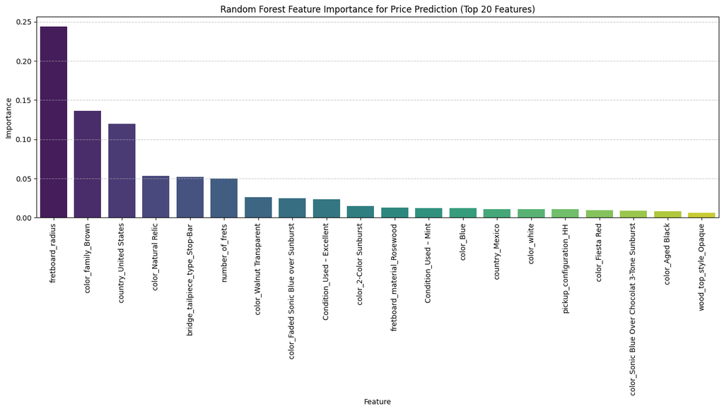

```
Generated bar chart for Random Forest feature importances.
```

```python
plt.figure(figsize=(14, 8)) # Set the figure size for the bar chart
sns.barplot(x=feature_importance_series.head(20).index, y=feature_importance_series.head(20).values, hue=feature_importance_series.head(20).index, palette='viridis', legend=False) # Create a bar plot using seaborn, showing the top 20 features, with hue and legend=False to prevent warnings
plt.xticks(rotation=90) # Rotate x-axis labels for better readability
plt.xlabel('Feature') # Set x-axis label
plt.ylabel('Importance') # Set y-axis label
plt.title('Random Forest Feature Importance for Price Prediction (Top 20 Features)') # Set the title of the plot
plt.grid(axis='y', linestyle='--', alpha=0.7) # Add a grid for better readability
plt.tight_layout() # Adjust layout to prevent labels from overlapping
plt.show() # Display the plot

print("Generated bar chart for Random Forest feature importances.")
```

### Analysis of Random Forest Feature Importances

The Random Forest feature importance bar chart provides a more nuanced view of the factors influencing guitar prices compared to the simple linear regression R-squared values. While linear regression assessed the individual linear relationship of each feature, Random Forest captures complex interactions and non-linear patterns, leading to potentially different and more robust importance rankings.

**Key Findings from Random Forest Feature Importances:**

**Comparison to Linear Regression Results:**

- **Higher Overall Predictive Power**: The Random Forest model's R-squared of 0.6728 indicates a much higher overall predictive power than any single feature's R-squared from the linear regression analysis. This confirms that guitar pricing is influenced by a complex interplay of multiple features, which Random Forest is better equipped to model.
- **Shift in Top Features' Relative Importance**: While `country_United States` and `color_family_Brown` remain significant in both models, numerical features like `fretboard_radius` and `number_of_frets` gain considerable importance in the Random Forest model. This suggests that their influence is often intertwined with other features, which a simple linear model cannot detect.
- **Specific Categories vs. General Features**: Random Forest also highlights the importance of very specific categories (e.g., `color_Natural Relic`), indicating that fine-grained details matter significantly in pricing.

**What Importance Values Signify:**

The importance values represent the contribution of each feature to the overall predictive accuracy of the Random Forest model. A higher importance score means that the feature is more frequently used in the decision-making process across the ensemble of trees, and it leads to a greater reduction in the error when splitting the data. These values are relative; they indicate which features the model relies on most, even if their individual linear correlation is low.